# **Natalidad en función del PIB por comunidad autónoma.**

Fuentes de datos Biomédicas y Web semánticas. Grado en Ingeniería de la Salud. Universidad de Burgos.

Lucía Vítores e Irene Gamazo

19 enero, 2022

# 1. Introducción

Este [repositorio](https://github.com/LuciaVitores/Prueba_seminario) ha sido creado para almacenar la información correspondiente a la natalidad por comunidades autónomas relacionada con los índices del producto interior burto (PIB) en España.

La información usada para realizar este trabajo ha sido obtenida en [Instituto Nacional de Estadística](https://www.ine.es/).

### **Natalidad.**

En demografía, sociología y geografía de la población, la tasa bruta de natalidad es una medida de cuantificación de la fecundidad. Se refiere a la relación que hay entre el número de nacimientos en un periodo determinado de tiempo y la cantidad total de población en un área geográfica determinada. Representa el número de individuos de una población que nacen vivos por unidad de tiempo.

Suele estudiarse en periodos de un año y el resultado se da en por cada mil habitates en ese tiempo.

La comparación de las tasa entre los diferenes paises o comunidades autónomas dentro de un mismo pais puede darnos información relevante.

### **PIB.**

Es una magnitud que expresa el valor monetario de la producción de bienes y servicios de demanda final de un país durante un periodo de tiempo determinado, generalmente de un año.

### **Relación.**

Nuestra hipótesis inicial es que, al contrario de lo que se podría esperar, cuanta mayor riqueza tenga una zona, mayor PIB tendrá y, por tanto, menor será la tasa de natalidad comparada con otras zonas con un PIB más bajo.

Vamos a comprobar la veracidad de esta hipótesis a lo largo del seminario mediante el uso de tablas y gráficos.

# 2. Objetivos.

Los principales objetivos de este repositorio son:

- Estudiar graficamente los niveles de natalidad desde 2016 hasta 2020 en cada comunidad autónoma española.
- Conocer el valor del PIB correspondiente a cada año en nuestras comunidades autónomas.
- Comparar el crecimiento económico de las 19 comunidades autónomas españolas.
- Relacionar estos niveles de natalidad en nuestro periodo de tiempo estudiado con los valores del PIB por comunidad autónoma.

# 3. Inserción de tablas y tratamiento de los datos.

Insertaremos las tablas con los datos obtenidos sobre la natalidad en las comunidades autónomas españolas entre los años 2016 y 2020, así como los valores del PIB correspondientes a estos años.

Primeros indicamos los paquetes de R que vamos a usar.

```r
#install.packages('DT')
library(readxl)
library(DT)
library(dplyr)
library(tidyverse)
library(ggplot2)
```

Los nombres de las filas de los datos que hemos descargado en INE, estaban compuesto por un número y el nombre de la comunidad autónoma. Para un mejor trabajo de los datos y unos resultados más claros y precisos, se han eliminado los números dejando únicamente el nombre. Para ello hemos usado la función **mutate**, donde hemos relacionado los **levels** (nombres que venían descritos) con los **labels** (nombres que queríamos dar).

## 3.1. *Tabla sobre el nacimiento en el año 2016.*

```r
X2016_2 <- read_excel("INPUT/Nacimiento - PIB/2016.2.xls") %>%
mutate(`Comunidades autónomas` = factor(`Comunidades autónomas`,
levels = c("01 Andalucía", "02 Aragón", "03 Asturias, Principado de", "04 Balears, Illes","05 Canarias", "06 Cantabria", "07 Castilla y León", "08 Castilla - La Mancha", "09 Cataluña", "10 Comunitat Valenciana","11 Extremadura", "12 Galicia", "13 Madrid, Comunidad de", "14 Murcia, Región de", "15 Navarra, Comunidad Foral de", "16 País Vasco", "17 Rioja, La", "18 Ceuta", "19 Melilla"),
labels = c("Andalucía", "Aragón", "Asturias", "Baleares", "Canarias", "Cantabria", "Castilla y León", "Castilla la Mancha", "Cataluña","Valencia", "Extremadura", "Galicia", "Madrid", "Murcia", "Navarra","Pais Vasco", "La Rioja", "Ceuta","Melilla")))


DT::datatable(X2016_2)
```

|  | Comunidades autónomas | Tipo de dato | Periodo | Total |
| --- | --- | --- | --- | --- |
| 1 | Andalucía | Dato base | 2016M12 | 6497 |
| 2 | Andalucía | Dato base | 2016M11 | 6620 |
| 3 | Andalucía | Dato base | 2016M10 | 6874 |
| 4 | Andalucía | Dato base | 2016M09 | 7069 |
| 5 | Andalucía | Dato base | 2016M08 | 7061 |
| 6 | Andalucía | Dato base | 2016M07 | 6825 |
| 7 | Andalucía | Dato base | 2016M06 | 6279 |
| 8 | Andalucía | Dato base | 2016M05 | 6249 |
| 9 | Andalucía | Dato base | 2016M04 | 6053 |
| 10 | Andalucía | Dato base | 2016M03 | 6693 |

[output cut: 218 more lines]

## 3.2. *Tabla sobre el nacimiento en el año 2017.*

```r
X2017_2 <- read_excel("INPUT/Nacimiento - PIB/2017.2.xls")%>%
mutate(`Comunidades autónomas` = factor(`Comunidades autónomas`,
levels = c("01 Andalucía", "02 Aragón", "03 Asturias, Principado de", "04 Balears, Illes","05 Canarias", "06 Cantabria", "07 Castilla y León", "08 Castilla - La Mancha", "09 Cataluña", "10 Comunitat Valenciana","11 Extremadura", "12 Galicia", "13 Madrid, Comunidad de", "14 Murcia, Región de", "15 Navarra, Comunidad Foral de", "16 País Vasco", "17 Rioja, La", "18 Ceuta", "19 Melilla"),
labels = c("Andalucía", "Aragón", "Asturias", "Baleares", "Canarias", "Cantabria", "Castilla y León", "Castilla la Mancha", "Cataluña","Valencia", "Extremadura", "Galicia", "Madrid", "Murcia", "Navarra","Pais Vasco", "La Rioja", "Ceuta","Melilla")))
DT::datatable(X2017_2)
```

|  | Comunidades autónomas | Tipo de dato | Periodo | Total |
| --- | --- | --- | --- | --- |
| 1 | Andalucía | Dato base | 2017M12 | 6256 |
| 2 | Andalucía | Dato base | 2017M11 | 6528 |
| 3 | Andalucía | Dato base | 2017M10 | 6816 |
| 4 | Andalucía | Dato base | 2017M09 | 6460 |
| 5 | Andalucía | Dato base | 2017M08 | 6379 |
| 6 | Andalucía | Dato base | 2017M07 | 6416 |
| 7 | Andalucía | Dato base | 2017M06 | 5848 |
| 8 | Andalucía | Dato base | 2017M05 | 5980 |
| 9 | Andalucía | Dato base | 2017M04 | 5786 |
| 10 | Andalucía | Dato base | 2017M03 | 6336 |

[output cut: 218 more lines]

## 3.3. *Tabla sobre el nacimiento en el año 2018.*

```r
X2018_2 <- read_excel("INPUT/Nacimiento - PIB/2018.2.xls")%>%
mutate(`Comunidades autónomas` = factor(`Comunidades autónomas`,
levels = c("01 Andalucía", "02 Aragón", "03 Asturias, Principado de", "04 Balears, Illes","05 Canarias", "06 Cantabria", "07 Castilla y León", "08 Castilla - La Mancha", "09 Cataluña", "10 Comunitat Valenciana","11 Extremadura", "12 Galicia", "13 Madrid, Comunidad de", "14 Murcia, Región de", "15 Navarra, Comunidad Foral de", "16 País Vasco", "17 Rioja, La", "18 Ceuta", "19 Melilla"),
labels = c("Andalucía", "Aragón", "Asturias", "Baleares", "Canarias", "Cantabria", "Castilla y León", "Castilla la Mancha", "Cataluña","Valencia", "Extremadura", "Galicia", "Madrid", "Murcia", "Navarra","Pais Vasco", "La Rioja", "Ceuta","Melilla")))
DT::datatable(X2018_2)
```

|  | Comunidades autónomas | Tipo de dato | Periodo | Total |
| --- | --- | --- | --- | --- |
| 1 | Andalucía | Dato base | 2018M12 | 5939 |
| 2 | Andalucía | Dato base | 2018M11 | 6105 |
| 3 | Andalucía | Dato base | 2018M10 | 6301 |
| 4 | Andalucía | Dato base | 2018M09 | 6039 |
| 5 | Andalucía | Dato base | 2018M08 | 6313 |
| 6 | Andalucía | Dato base | 2018M07 | 6116 |
| 7 | Andalucía | Dato base | 2018M06 | 5649 |
| 8 | Andalucía | Dato base | 2018M05 | 5776 |
| 9 | Andalucía | Dato base | 2018M04 | 5571 |
| 10 | Andalucía | Dato base | 2018M03 | 5722 |

[output cut: 218 more lines]

## 3.4. *Tabla sobre el nacimiento en el año 2019.*

```r
X2019_2 <- read_excel("INPUT/Nacimiento - PIB/2019.2.xls")%>%
mutate(`Comunidades autónomas` = factor(`Comunidades autónomas`,
levels = c("01 Andalucía", "02 Aragón", "03 Asturias, Principado de", "04 Balears, Illes","05 Canarias", "06 Cantabria", "07 Castilla y León", "08 Castilla - La Mancha", "09 Cataluña", "10 Comunitat Valenciana","11 Extremadura", "12 Galicia", "13 Madrid, Comunidad de", "14 Murcia, Región de", "15 Navarra, Comunidad Foral de", "16 País Vasco", "17 Rioja, La", "18 Ceuta", "19 Melilla"),
labels = c("Andalucía", "Aragón", "Asturias", "Baleares", "Canarias", "Cantabria", "Castilla y León", "Castilla la Mancha", "Cataluña","Valencia", "Extremadura", "Galicia", "Madrid", "Murcia", "Navarra","Pais Vasco", "La Rioja", "Ceuta","Melilla")))
DT::datatable(X2019_2)
```

|  | Comunidades autónomas | Tipo de dato | Periodo | Total |
| --- | --- | --- | --- | --- |
| 1 | Andalucía | Dato base | 2019M12 | 5750 |
| 2 | Andalucía | Dato base | 2019M11 | 5769 |
| 3 | Andalucía | Dato base | 2019M10 | 6357 |
| 4 | Andalucía | Dato base | 2019M09 | 5983 |
| 5 | Andalucía | Dato base | 2019M08 | 6154 |
| 6 | Andalucía | Dato base | 2019M07 | 5719 |
| 7 | Andalucía | Dato base | 2019M06 | 5176 |
| 8 | Andalucía | Dato base | 2019M05 | 5703 |
| 9 | Andalucía | Dato base | 2019M04 | 5663 |
| 10 | Andalucía | Dato base | 2019M03 | 5780 |

[output cut: 218 more lines]

## 3.5. *Tabla sobre el nacimiento en el año 2020.*

```r
X2020_2 <- read_excel("INPUT/Nacimiento - PIB/2020.2.xls")%>%
mutate(`Comunidades autónomas` = factor(`Comunidades autónomas`,
levels = c("01 Andalucía", "02 Aragón", "03 Asturias, Principado de", "04 Balears, Illes","05 Canarias", "06 Cantabria", "07 Castilla y León", "08 Castilla - La Mancha", "09 Cataluña", "10 Comunitat Valenciana","11 Extremadura", "12 Galicia", "13 Madrid, Comunidad de", "14 Murcia, Región de", "15 Navarra, Comunidad Foral de", "16 País Vasco", "17 Rioja, La", "18 Ceuta", "19 Melilla"),
labels = c("Andalucía", "Aragón", "Asturias", "Baleares", "Canarias", "Cantabria", "Castilla y León", "Castilla la Mancha", "Cataluña","Valencia", "Extremadura", "Galicia", "Madrid", "Murcia", "Navarra","Pais Vasco", "La Rioja", "Ceuta","Melilla")))
DT::datatable(X2020_2)
```

|  | Comunidades autónomas | Tipo de dato | Periodo | Total |
| --- | --- | --- | --- | --- |
| 1 | Andalucía | Dato base | 2020M12 | 4528 |
| 2 | Andalucía | Dato base | 2020M11 | 5152 |
| 3 | Andalucía | Dato base | 2020M10 | 5816 |
| 4 | Andalucía | Dato base | 2020M09 | 5688 |
| 5 | Andalucía | Dato base | 2020M08 | 5565 |
| 6 | Andalucía | Dato base | 2020M07 | 5699 |
| 7 | Andalucía | Dato base | 2020M06 | 5437 |
| 8 | Andalucía | Dato base | 2020M05 | 5388 |
| 9 | Andalucía | Dato base | 2020M04 | 5288 |
| 10 | Andalucía | Dato base | 2020M03 | 5585 |

[output cut: 218 more lines]

## 3.6. *Tabla sobre el PIB.*

```r
PIB2 <- read_excel("INPUT/Nacimiento - PIB/PIB2.xls")
names(PIB2)[names(PIB2) == 'Comunidades y ciudades autónomas'] <- 'Comunidades autónomas'
PIB2$periodo[PIB2$periodo == "2018 (P)"] <- "2018"
PIB2$periodo[PIB2$periodo == "2019 (A)"] <- "2019"

DT::datatable(PIB2)
```

|  | Comunidades autónomas | Ramas de actividad | periodo | Total |
| --- | --- | --- | --- | --- |
| 1 | Andalucía | PRODUCTO INTERIOR BRUTO A PRECIOS DE MERCADO | 2019 | 165865509 |
| 2 | Andalucía | PRODUCTO INTERIOR BRUTO A PRECIOS DE MERCADO | 2018 | 160711363 |
| 3 | Andalucía | PRODUCTO INTERIOR BRUTO A PRECIOS DE MERCADO | 2017 | 155371755 |
| 4 | Andalucía | PRODUCTO INTERIOR BRUTO A PRECIOS DE MERCADO | 2016 | 148405362 |
| 5 | Andalucía | PRODUCTO INTERIOR BRUTO A PRECIOS DE MERCADO | 2015 | 144745569 |
| 6 | Aragón | PRODUCTO INTERIOR BRUTO A PRECIOS DE MERCADO | 2019 | 38043571 |
| 7 | Aragón | PRODUCTO INTERIOR BRUTO A PRECIOS DE MERCADO | 2018 | 36850296 |
| 8 | Aragón | PRODUCTO INTERIOR BRUTO A PRECIOS DE MERCADO | 2017 | 35638352 |
| 9 | Aragón | PRODUCTO INTERIOR BRUTO A PRECIOS DE MERCADO | 2016 | 34214691 |
| 10 | Aragón | PRODUCTO INTERIOR BRUTO A PRECIOS DE MERCADO | 2015 | 32876311 |

[output cut: 90 more lines]

Hemos cambiado el nombre de la columna de *Comunidades y ciudades autónomas* por *Comunidades autónomas* para poder obtener el mismo nombre de columna en todas nuestras tablas y poder trabajar con más facilidad en los objetivos a cumplir.

# 4. Desarrollo de los Objetivos.

## Objetivo 1: Estudio gráfico sobre la natalidad.

```r
data("X2016_2")
```

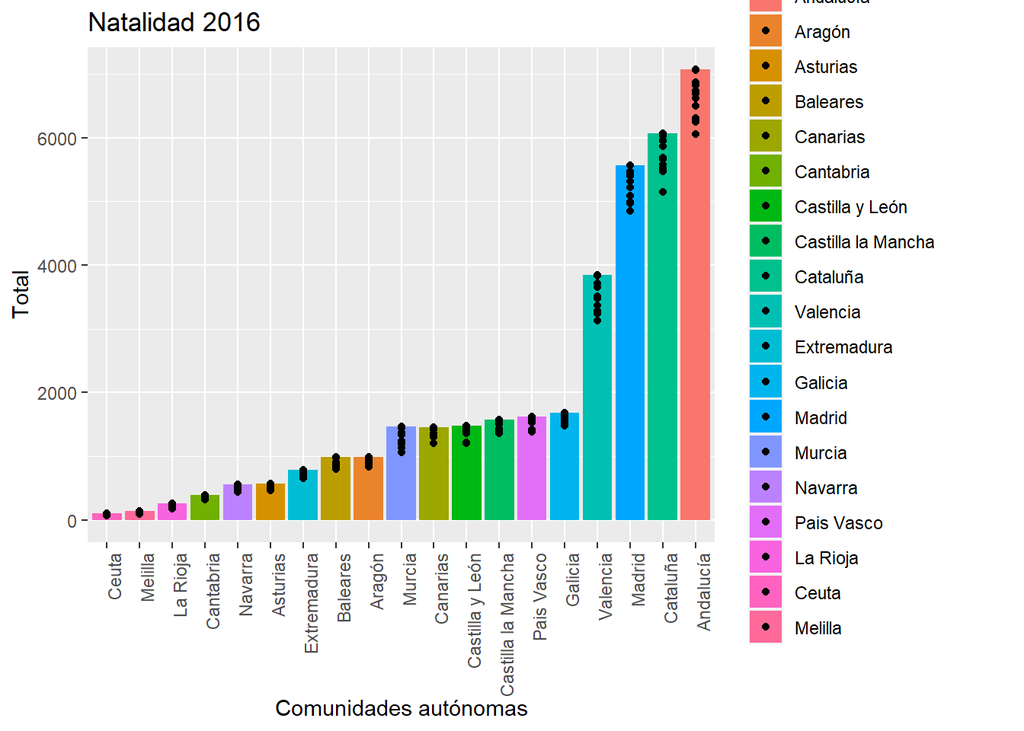

```r
ggplot(data=X2016_2, aes(x=reorder(`Comunidades autónomas`, Total), y=Total, fill=`Comunidades autónomas`)) + theme(axis.text.x = element_text(angle = 90, hjust = 1)) +
    geom_bar(stat="identity", position="dodge") +
  geom_point() +
  labs(
    title = "Natalidad 2016",
    x = "Comunidades autónomas",
    y = "Total"
  )
```

En 2016, podemos observar que la comunidad con mayores cifras de natalidad es **Andalucía** con unos valores que superan los 7000 puntos, seguida de **Cataluña** que sobrepasa los 6000 nacimientos dependiendo del mes y **Madrid** con valores que rondan siempre los 5000 nacimientos.La cuarta comunidad con mayor puntuación es **Valencia** que muestra valores entre los 3000 y 4000 nacimientos.

Por otra parte, las comunidades que menos nacimientos registran son: **Ceuta** con valores que generalmente no pasan de los 100 nacimientos y **Melilla** que presenta entre 100 y 150 nacimientos cada mes. **La Rioja**, **Cantabria**, **Asturias**, **Navarra**, **Baleares**, **Extremadura** y **Aragón** se encuentran dentro de unos valores parecidos que no superan los 1000 nacimientos en ningún mes de 2016. Por último, **Canarias**, **Castilla y León** , **Castilla la Mancha**, **Galicia**, **Murcia** y **País Vasco** también presentan valores similares entre los 1000 y los 2000 nacimientos cada mes.

Podemos observar que no hay mucha separación entre las natalides de los meses en un mismo año. Las comunidades que más variaciones ha sufrido en este año han sido **Cataluña** y **Andalucía**, ya que en el resto de ellas se ve que apenas hay variaciones entre los meses.

```r
data("X2017_2")
```

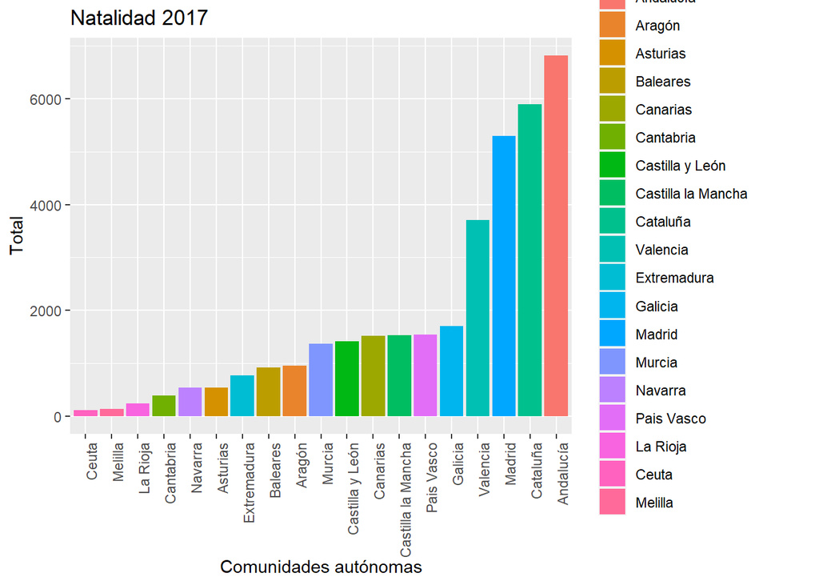

```r
ggplot(data=X2017_2, aes(x=reorder(`Comunidades autónomas`, Total ), y=Total, fill=`Comunidades autónomas`)) + theme(axis.text.x = element_text(angle = 90, hjust = 1)) +
    geom_bar(stat="identity", position="dodge") +
  labs(
    title = "Natalidad 2017",
    x = "Comunidades autónomas",
    y = "Total"
  )
```

En 2017 los resultados son similares a los que encontrábamos en 2016. **Andalucía**, **Cataluña**, **Madrdid** y **Valencia** son las comunidades con más nacimientos, con la diferencia de que en Andalucía, este año hay meses en los que apenas se alcanzan los 6000 nacimientos.

**Ceuta** y **Melilla** siguen siendo las cominidades con menor natalidad. Y el resto de comunidades se mantienen dentro de los mismos valores que podíamos observar en 2016.

```r
data("X2018_2")
```

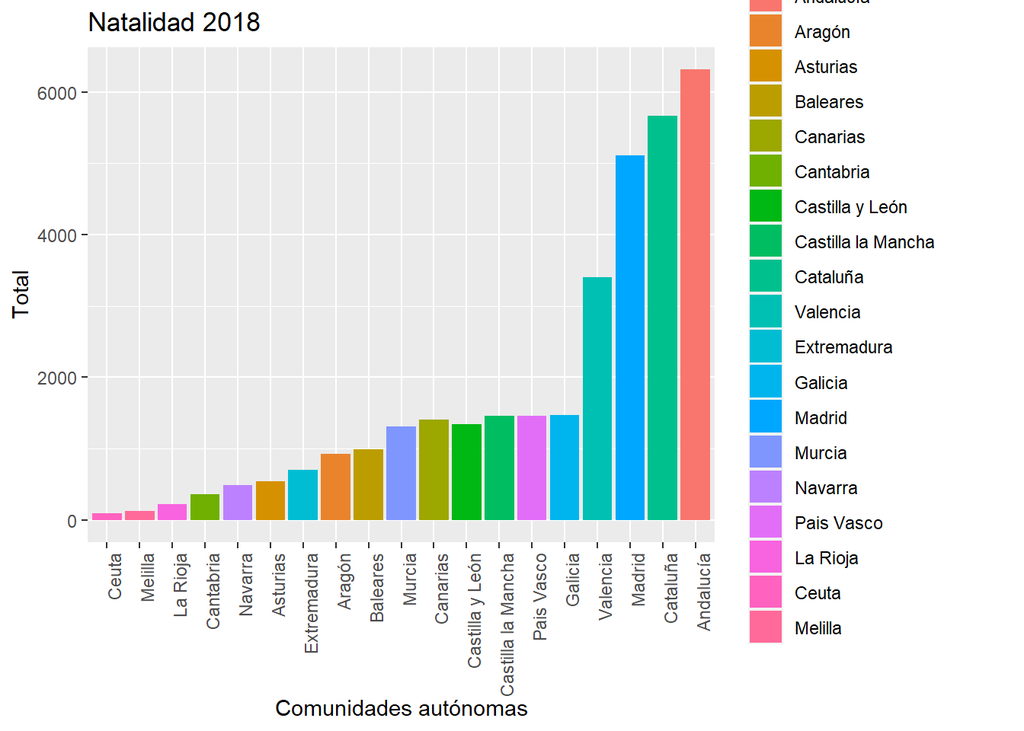

```r
ggplot(data=X2018_2, aes(x=reorder(`Comunidades autónomas`, Total ), y=Total, fill=`Comunidades autónomas`)) + theme(axis.text.x = element_text(angle = 90, hjust = 1)) +
    geom_bar(stat="identity", position="dodge") +
  labs(
    title = "Natalidad 2018",
    x = "Comunidades autónomas",
    y = "Total"
  )
```

En 2018 vemos que los valores también son parecidos a los encontrados en los dos años anteriores, pero observamos que en las cuatro comunidades que presentan mayor natalidad las puntuaciones han bajado. Por ejemplo, encontramos en **Andalucía** puntuaciones poco superiores a los 5000 nacimientos en algunos meses.

Los valores de **Ceuta** y **Melilla** siguen siendo similares al igual que en el resto de comunidades.

```r
data("X2019_2")
```

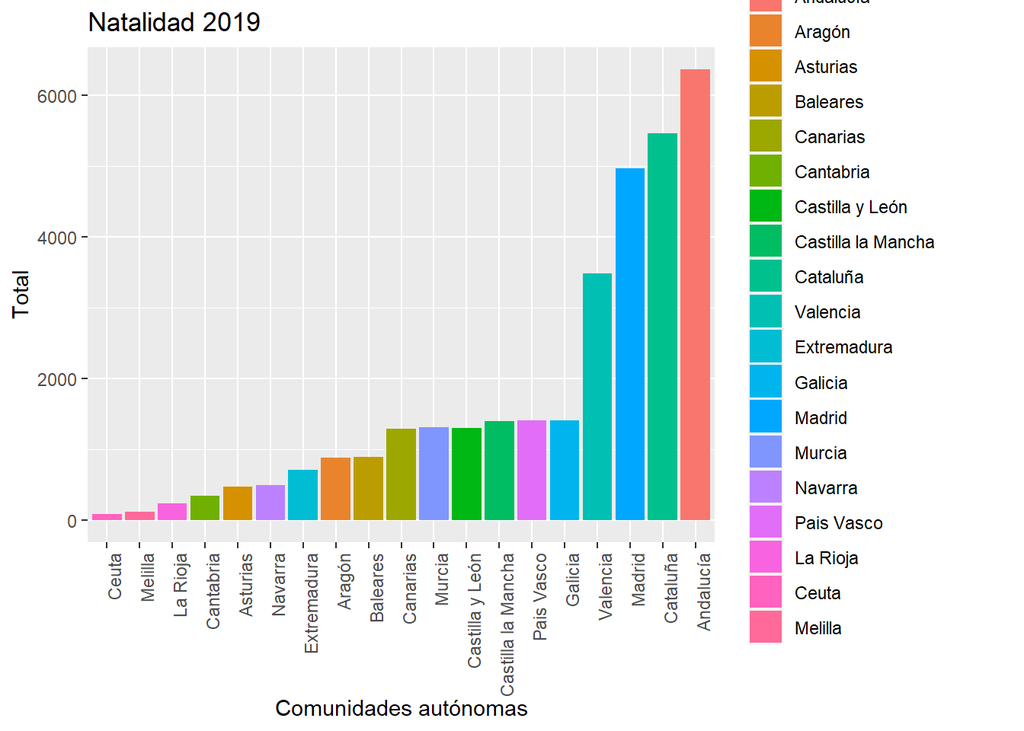

```r
ggplot(data=X2019_2, aes(x=reorder(`Comunidades autónomas`, Total ), y=Total, fill=`Comunidades autónomas`)) + theme(axis.text.x = element_text(angle = 90, hjust = 1)) +
    geom_bar(stat="identity", position="dodge") +
  labs(
    title = "Natalidad 2019",
    x = "Comunidades autónomas",
    y = "Total"
  )
```

```r
data("X2020_2")
```

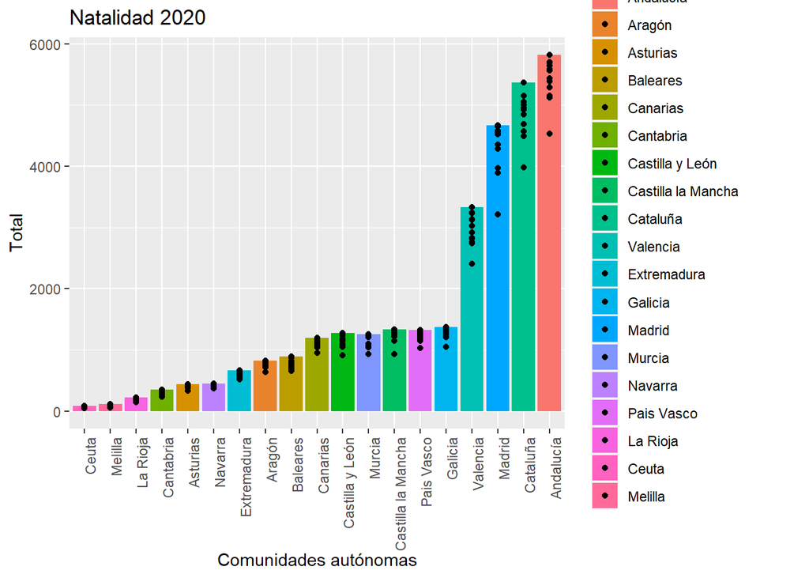

```r
ggplot(data=X2020_2, aes(x=reorder(`Comunidades autónomas`, Total ), y=Total, fill=`Comunidades autónomas`)) + theme(axis.text.x = element_text(angle = 90, hjust = 1)) +
  geom_bar(stat="identity", position="dodge") +
  geom_point() +
  labs(
    title = "Natalidad 2020",
    x = "Comunidades autónomas",
    y = "Total"
  )
```

Podemos comprobar que los resultados se mantienen constantes a lo largo de los años, pero cada vez es más observable el descenso de la natalidad. En este año es mucho más fácil de observar la diferencia entre las natalidades durante los meses. Las separaciones cada vez son más grandes, lo que indica que hay meses en los que la natalidad es relativamente baja.Donde mejor podemos observarlo es en **Madrid**. Aunque en comparación con el año 2016, todas las comunidades han sufrido una gran bajada.

Hasta aquí cumplimos el primer objetivo, ya que hemos representado gráficamente los valores de natalidad entre 2016 y 2020. Los resultado generales han demostrado que la natalidad se mantiene dentro de unos valores más o menos constantes a lo largo de los años, aunque es importante recalcar que ha comenzado disminuir.

Aunque los valores de natalidad sean cada año un poco menores, **Andalucía**, **Cataluña** y **Madrid** son las comunidades con los niveles más altos y **Ceuta** y **Melilla** aquellas en los que se producen menos nacimientos.

```r
natalidad <- rbind(X2016_2, X2017_2, X2018_2, X2019_2, X2020_2)
DT::datatable(natalidad)
```

|  | Comunidades autónomas | Tipo de dato | Periodo | Total |
| --- | --- | --- | --- | --- |
| 1 | Andalucía | Dato base | 2016M12 | 6497 |
| 2 | Andalucía | Dato base | 2016M11 | 6620 |
| 3 | Andalucía | Dato base | 2016M10 | 6874 |
| 4 | Andalucía | Dato base | 2016M09 | 7069 |
| 5 | Andalucía | Dato base | 2016M08 | 7061 |
| 6 | Andalucía | Dato base | 2016M07 | 6825 |
| 7 | Andalucía | Dato base | 2016M06 | 6279 |
| 8 | Andalucía | Dato base | 2016M05 | 6249 |
| 9 | Andalucía | Dato base | 2016M04 | 6053 |
| 10 | Andalucía | Dato base | 2016M03 | 6693 |

[output cut: 1130 more lines]

Una vez obtenida dicha tabla, creamos una nueva que agrupe por comunidades autónomas y cree una nueva columna dentro de esta llamada *natalidad_promedio* que tenga la media del total de cada comunidad.

```r
nuevaNatalidad <- natalidad %>%
  group_by(`Comunidades autónomas`) %>%
  summarise(natalidad_promedio  = mean(Total))
DT::datatable(nuevaNatalidad)
```

|  | Comunidades autónomas | natalidad_promedio |
| --- | --- | --- |
| 1 | Andalucía | 5987.98333333333 |
| 2 | Aragón | 835.383333333333 |
| 3 | Asturias | 466.95 |
| 4 | Baleares | 837.45 |
| 5 | Canarias | 1233.2 |
| 6 | Cantabria | 318.333333333333 |
| 7 | Castilla y León | 1253.08333333333 |
| 8 | Castilla la Mancha | 1339.68333333333 |
| 9 | Cataluña | 5314.18333333333 |
| 10 | Valencia | 3220.7 |

[output cut: 9 more lines]

Observamos gráficamente los resultados:

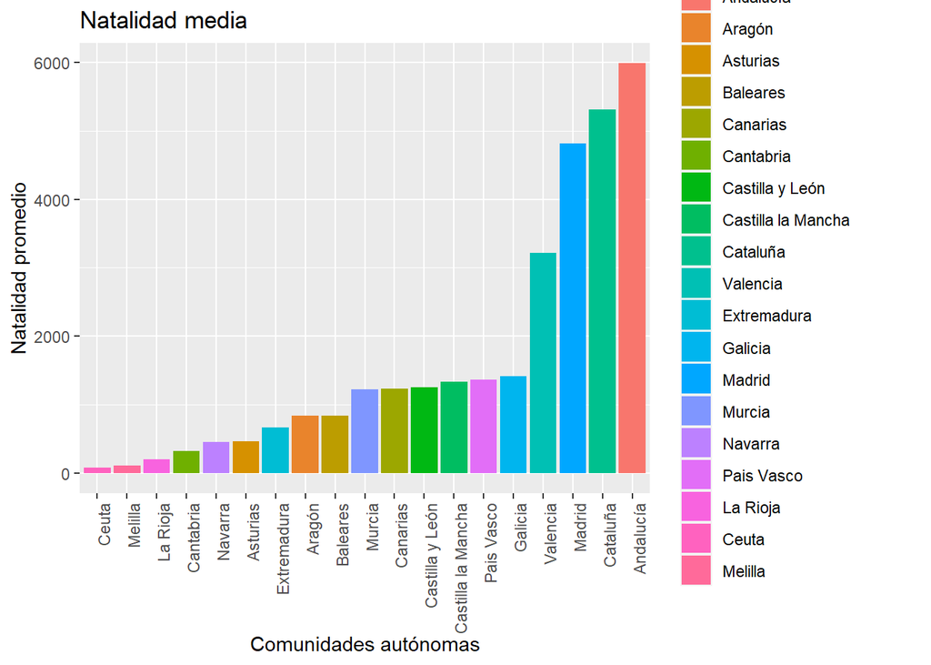

```r
ggplot(data=nuevaNatalidad, aes(x=reorder(`Comunidades autónomas`, natalidad_promedio ), y=natalidad_promedio, fill=`Comunidades autónomas`)) +
  theme(axis.text.x = element_text(angle = 90, hjust = 1)) +
    geom_bar(stat="identity", position="dodge") +
  labs(
    title = "Natalidad media",
    x = "Comunidades autónomas",
    y = "Natalidad promedio"
  )
```

En esta gráfica podemos observar la media de la natalidad de las distintas comunidades y ciudades autónomas. Podemos ver que los resultados obtenidos en la media coinciden con los obtenidos en el resto de las tablas.Se sigue manteniendo que **Andalucía**, **Cataluña**, **Madrid** y **Valencia** son las que mayor natalidad tienen, mientras que las que menos son **Ceuta** y **Melilla**.

## Objetivo 2: PIB por año.

En este objetivo hemos decidido mostrar los datos en función de los años en vez de las comunidades autónomas porque el número de tablas que creamos es menor y nos muestran la misma información. Para ello, a apartir del dataframe en el que teníamos los datos del PIB, creamos un nuevo dataframe por cada año. Y posteriormente mostramos los datos gráficamente.

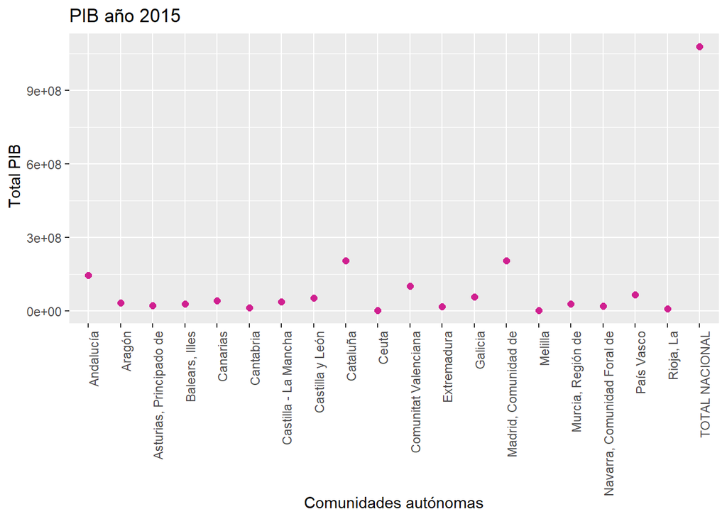

```r
PIB_2015 <- PIB2%>%
  filter( periodo == "2015") %>%
  select( `Comunidades autónomas`, Total )

ggplot(PIB_2015, aes(x=`Comunidades autónomas`, y=Total )) +
  theme(axis.text.x = element_text(angle = 90, hjust = 1)) +
  geom_point(size=2, shape=21,fill="violetred", colour="violetred") +
   labs(
     title = "PIB año 2015",
     x = "Comunidades autónomas",
     y = " Total PIB")
```

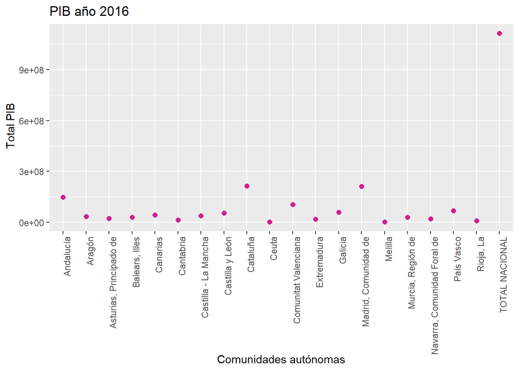

```r
PIB_2016 <- PIB2%>%
  filter( periodo == "2016") %>%
  select( `Comunidades autónomas`, Total )

ggplot(PIB_2016, aes(x=`Comunidades autónomas`, y=Total )) +
  theme(axis.text.x = element_text(angle = 90, hjust = 1)) +
  geom_point( size=2, shape=21, fill="violetred", colour="violetred") +
   labs(
    title = "PIB año 2016",
     x = "Comunidades autónomas",
     y = " Total PIB")
```

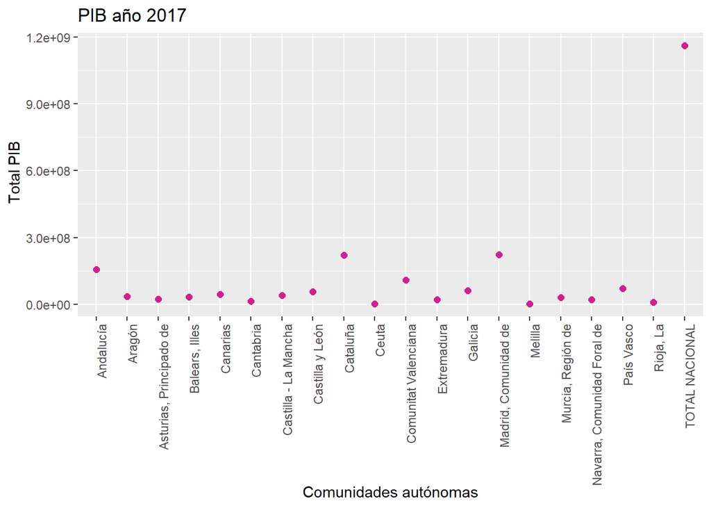

```r
PIB_2017 <- PIB2%>%
  filter( periodo == "2017") %>%
  select( `Comunidades autónomas`, Total )

ggplot(PIB_2017, aes(x=`Comunidades autónomas`, y=Total )) +
  theme(axis.text.x = element_text(angle = 90, hjust = 1)) +
  geom_point( size=2, shape=21, fill="violetred", colour="violetred") +
   labs(
    title = "PIB año 2017",
     x = "Comunidades autónomas",
     y = " Total PIB")
```

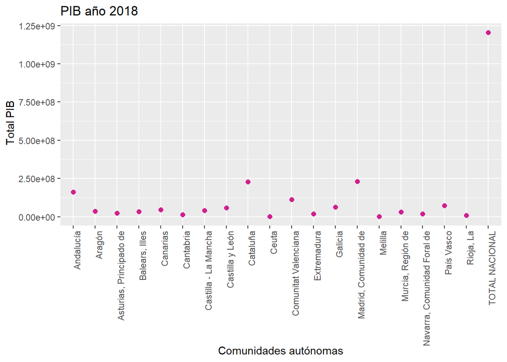

```r
PIB_2018 <- PIB2%>%
  filter( periodo == "2018") %>%
  select( `Comunidades autónomas`, Total )

ggplot(PIB_2018, aes(x=`Comunidades autónomas`, y=Total )) +
  theme(axis.text.x = element_text(angle = 90, hjust = 1)) +
  geom_point(size=2, shape=21,fill="violetred", colour="violetred") +
   labs(
     title = "PIB año 2018",
      x = "Comunidades autónomas",
      y = " Total PIB")
```

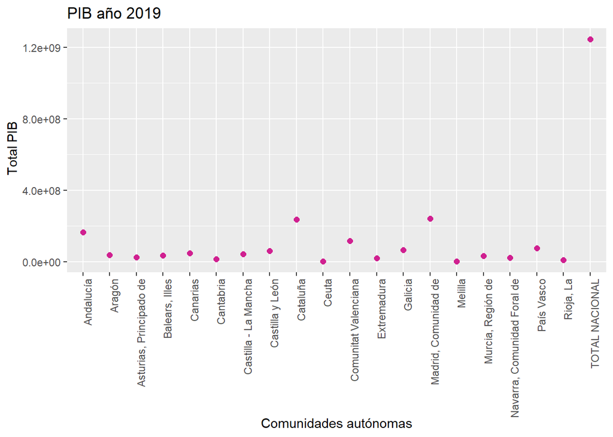

```r
PIB_2019 <- PIB2%>%
  filter( periodo == "2019") %>%
  select( `Comunidades autónomas`, Total )
ggplot(PIB_2019, aes(x=`Comunidades autónomas`, y=Total )) +
  theme(axis.text.x = element_text(angle = 90, hjust = 1)) +
  geom_point(size=2, shape=21,fill="violetred", colour="violetred") +
   labs(
     title = "PIB año 2019",
      x = "Comunidades autónomas",
      y = " Total PIB")
```

Podemos ver que en todos los casos los resultados son más o menos constantes.

## Objetivo 3 : Comparar PIB.

```r
data("PIB2")
```

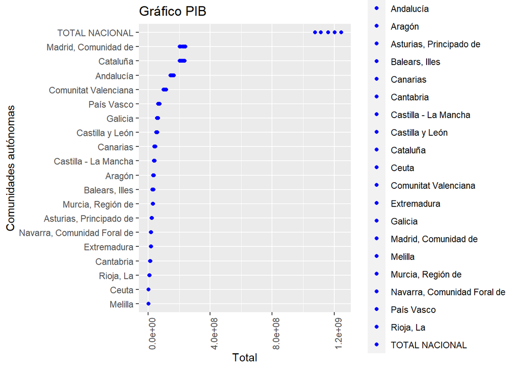

```r
  ggplot(data=PIB2, aes(x=reorder(`Comunidades autónomas`, Total ), y=Total, fill=`Comunidades autónomas`)) + theme(axis.text.x = element_text(angle = 90, hjust = 1)) +
  geom_point(colour = "blue") +
  labs(
    title = "Gráfico PIB",
    x = "Comunidades autónomas",
    y = "Total"
  ) +
    coord_flip()
```

En este caso, con una sola tabla podemos comparar el PIB de todas las comunidades autónomas.

Están ordenadas de tal forma que aquellas con un PIB más bajo estén abajo del todo y según se vaya ascendiendo, encontraremos comunidades autónomas con cada vez más PIB hasta llegar al total.

## Objetivo 4 : Relaciónar PIB y natalidad.

Una vez que ya hemos estudiado por separado los valores de natalidad y PIB, vamos a ponerlos en común para ver como evolucionan y si se cumple con la hipótesis planteada al principio. Para ello relacionamos las dos tablas con las que queremos trabajar, PIB2 y nuevaNatalidad (tabla creada anteriormente que almacena la información relacionada con la media total del nacimiento en cada comunidad) en un únidco dataframe **relacion**.

```r
relacion <- left_join(x = nuevaNatalidad, y = PIB2)
relacion
```

| Comunidades autónomas | natalidad_promedio | Ramas de actividad | periodo | Total |
| --- | --- | --- | --- | --- |
| Andalucía | 5987.9833 | PRODUCTO INTERIOR BRUTO A PRECIOS DE MERCADO | 2019 | 165865509 |
| Andalucía | 5987.9833 | PRODUCTO INTERIOR BRUTO A PRECIOS DE MERCADO | 2018 | 160711363 |
| Andalucía | 5987.9833 | PRODUCTO INTERIOR BRUTO A PRECIOS DE MERCADO | 2017 | 155371755 |
| Andalucía | 5987.9833 | PRODUCTO INTERIOR BRUTO A PRECIOS DE MERCADO | 2016 | 148405362 |
| Andalucía | 5987.9833 | PRODUCTO INTERIOR BRUTO A PRECIOS DE MERCADO | 2015 | 144745569 |
| Aragón | 835.3833 | PRODUCTO INTERIOR BRUTO A PRECIOS DE MERCADO | 2019 | 38043571 |
| Aragón | 835.3833 | PRODUCTO INTERIOR BRUTO A PRECIOS DE MERCADO | 2018 | 36850296 |
| Aragón | 835.3833 | PRODUCTO INTERIOR BRUTO A PRECIOS DE MERCADO | 2017 | 35638352 |
| Aragón | 835.3833 | PRODUCTO INTERIOR BRUTO A PRECIOS DE MERCADO | 2016 | 34214691 |
| Aragón | 835.3833 | PRODUCTO INTERIOR BRUTO A PRECIOS DE MERCADO | 2015 | 32876311 |

[output cut: 49 more lines]

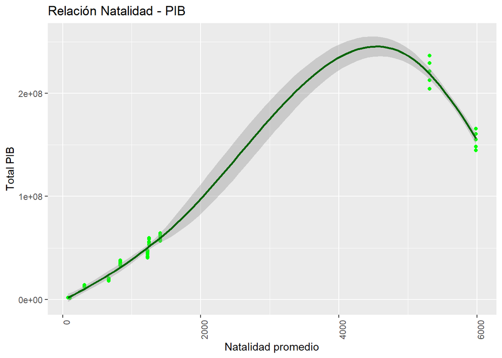

```r
ggplot(data=relacion, aes(x= natalidad_promedio, y=Total )) +
  theme(axis.text.x = element_text(angle = 90, hjust = 1)) +
  geom_point(colour = "green") +
  geom_smooth(colour = " darkgreen") +
  labs(
    title = "Relación Natalidad - PIB",
    x = "Natalidad promedio",
    y = "Total PIB"
  )
```

Para poder estudiar la gráfica final, debemos saber que hay otros factores que alteran los resultados, como por ejemplo la superficie de cada comunidad autónoma.

# 5. Conclusiones.

Hemos estudiado la natalidad en las diferentes comunidades autónomas españolas y hemos podido comprobar que aunque generalmente, los valores se mantienen constantes dentro de unos rangos, el número de nacimientos es cada vez menor.